# STA 138 Final Project

Ying-Chen Chou

## I. Introduction

For problem 1, we use the student dataset to explore the relationship between socioeconomic classs and other variables. We will fit a multinominal model and select the best model through backward-forward subset selection and use AIC as a criterina. Model diagnostic procedure would be done to identify potential outliers and influential points. Also, we will use the selected model to do prediction.

## II. Summary

##### Response Variable

The ses variables stand for socioeconomic classs for students. It is the response variable for this project. ses has three levels including high, middle, and low. From the following table, you can clearly have a understanding of how many counts for each level. Also, from the barplot, level middle one has the highest count among three levels. Level low has the least counts.

| Levels | High | Middle | Low |
| --- | --- | --- | --- |
| Counts | 58 | 95 | 47 |

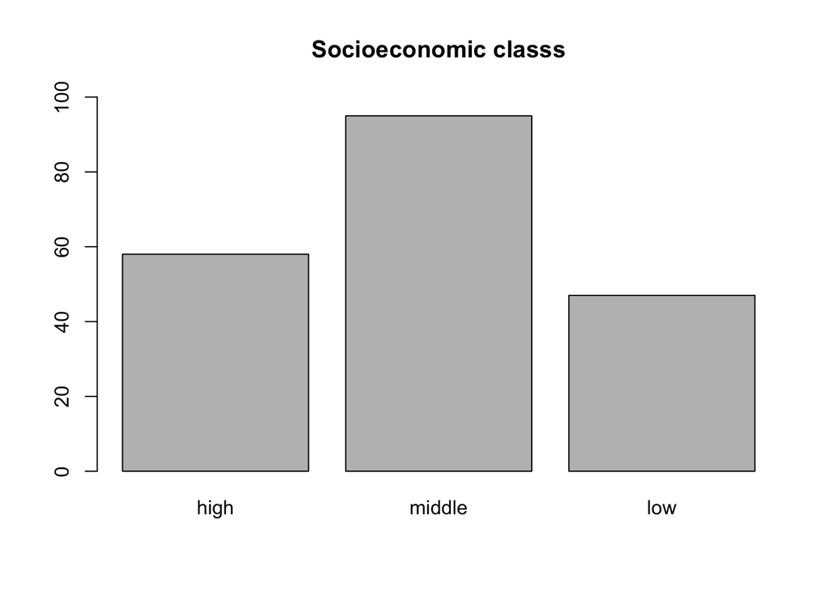

##### Predictor variables

In students data, there are 7 predictor variables. Among them, gender, schtyp, and honors are categorical. The others are continuous. There are two types of gender which are male and female. schtyp also has two levels, which are public and private. For honor, there are two levels with yes and no representing whether or not the student is enrolled in an honors class. Here are tables for three categorical variables. From the table and bar plot for each one, we can have a roughly understanding of the distribution of the variables. There are more female in the data. Most of the observations went to public school. Also, most of the students are not enrolled in an honors class.

| Gender | Male | Female |
| --- | --- | --- |
| Counts | 91 | 109 |

| School Type | Public | Private |
| --- | --- | --- |
| Counts | 168 | 32 |

| Honor | Yes | No |
| --- | --- | --- |
| Counts | 53 | 147 |

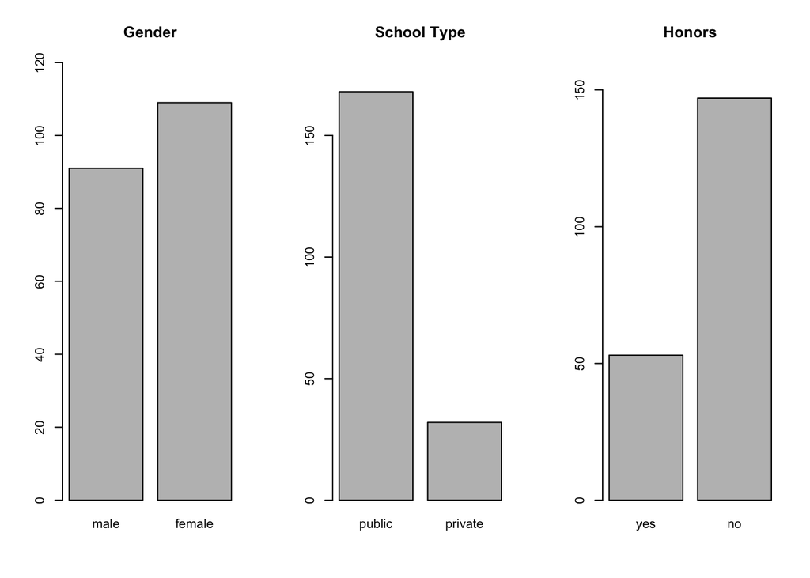

For continuous variables, variables are score of different subjects. The histogram showed that Read is slightly right skewed, write is slightly left skewed, while the other two are nearly normal.

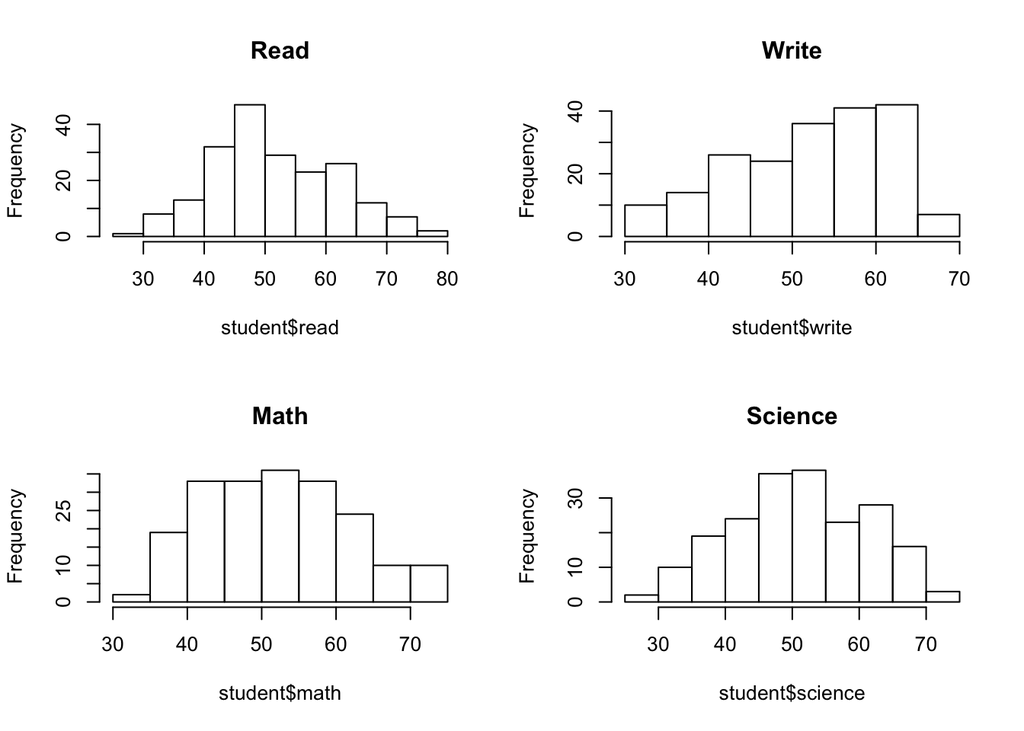

## III. Analysis

##### Model Fitting and model selection

Since we have 7 predictor variables, it’s time consuming to do all subset algorithm because there will be $2^7 = 128$ combination of models. Instead, we implemented backward-forward subset selection and use AIC as a criteria. This combination of model selection can help us find the predictive model. After this, we will do hypothesis testing to check if the selected model fits well.

| Models | LL | DF | AIC | BIC |
| --- | --- | --- | --- | --- |
| Null | -210.5825 | 198 | 425.1651 | 431.7617 |
| Selected | -191.8765 | 190 | 403.7529 | 436.7361 |
| Models | -189.6085 | 184 | 411.2169 | 463.9900 |

$H_0$: Selected model fits well

$H_1$: Full model fits well

Test Statistic = $G^2 = -2(L_0 - L_1) = -2(-191.8765 - (-189.6085))) = 4.536$ with degree of freedom = 6. The corresponding p value is 0.6045.

##### Selected model

Since p-value > 0.05, we fail to reject $H_0$ and we can conclude that the selected model fits well. The selected model is the model with variables including gender, schtyp, read, and honors.

After model fitting, we now have the following models for the two log-odds:

$ln(\frac{\pi_{Low(x)}}{\pi_{High(x)}}) = 2.6444 -0.8675Gender_M + 1.6367Sch_{pub} -0.0740read -0.2937honors_{yes}$

$ln(\frac{\pi_{Middle(x)}}{\pi_{High(x)}}) = 2.3046 -0.1911Gender_M -0.0463Sch_{pub} -0.0247read -1.1707honors_{yes}$

Where

$Gender_M = \left \{ \begin{array}{ll}1 & \text{if Male}\\ 0 & \text{if Female} \end{array} \right.$, $Sch_{pub} = \left \{ \begin{array}{ll}1 & \text{if Public}\\ 0 & \text{if Private} \end{array} \right.$, and $honors_{yes} = \left \{ \begin{array}{ll}1 & \text{if Yes}\\ 0 & \text{if No} \end{array} \right.$

##### Confidence interval

The confidence interval for $\beta's$ are :

```
## , , low
##
##                    2.5 %       97.5 %
## (Intercept)  -0.24282977  5.531667638
## gendermale   -1.72806231 -0.006998487
## schtyppublic  0.03765038  3.235814731
## read         -0.12360277 -0.024467154
## honorsyes    -1.35042458  0.763015878
##
## , , middle
##
##                   2.5 %      97.5 %
## (Intercept)   0.1291376  4.48005772
## gendermale   -0.8949048  0.51273738
## schtyppublic -0.9148289  0.82230270
## read         -0.0635126  0.01410079
## honorsyes    -2.0343238 -0.30699225
```

The confidence interval for $exp(\beta)'s$ are :

```
## , , low
##
##                  2.5 %      97.5 %
## (Intercept)  0.7844050 252.5647466
## gendermale   0.1776283   0.9930259
## schtyppublic 1.0383681  25.4270796
## read         0.8837308   0.9758297
## honorsyes    0.2591302   2.1447347
##
## , , middle
##
##                  2.5 %     97.5 %
## (Intercept)  1.1378466 88.2397654
## gendermale   0.4086465  1.6698560
## schtyppublic 0.4005852  2.2757342
## read         0.9384623  1.0142007
## honorsyes    0.1307689  0.7356563
```

##### Goodness of Fit test

After fitting models, we split the data into two group. First group contains those in middle and high socioeconomic class and second group contains those in low and high socioeconomic class. Then we fit two logistic model seperatly for each group and do model diagnostic for each of them to test if the model fits well and also find out the potential influential points.

For Hosmer and Lemeshow goodness of fit test, the null hypothesis is $H_0$: the logistic model fits well and the alternative hypothesis if $H_1$: the logistic model did not fit well. We do the hypothesis test for both logistic regression model. For the first group (Middle and High), the test statistis is 2.2847 with 6 degree of freedom and p-value = 0.8917. For second group (Low and High), the test statistis is 3.1525 with 6 degree of freedom and p-value = 0.7895.

## IV. Interpretation

From the above analysis, we can have the following summaries:

**For First Models (Low vs High)**

About the confidence interval of $\beta$’s, only the confidence interval for $\beta_4$(honor) covers zero. This implies that honor was not a significant predictor. And from the confidence intervals of $exp(\beta)$’s, only the confidence interval for $exp(\beta_4)$(honor) covers 1. We can conclude that except honors, all other predictor might have effect on whether a student is in low socioeconomic calss or high one.

**For Second Models**

About the confidence interval of $\beta$’s, only that of $\beta_4$(honor) didn’t contain zero. Honor might be a significant predictor. About the confidence interval of $exp(\beta)$’s, only the one about honors did not cover 1. This also implies that honors might be have an effect on if the student is in middle class or high.

**Prediction**

For a female, who scored 60 on all her tests, who went to private school, and who was not in the honors program will have the following probability in three levels of socioeconomic class respectively.

| Socioeconomic class | Low | Middle | High |
| --- | --- | --- | --- |
| Probability | 0.0481 | 0.6613 | 0.2906 |

**Model Diagnostics**

| Observations | gender | schtyp | read | write | math | science | honors |
| --- | --- | --- | --- | --- | --- | --- | --- |
| 58 | female | private | 36 | 57 | 42 | 50 | no |
| 107 | female | private | 60 | 54 | 50 | 50 | no |

3. Error rate is 0.45
4. The error matrix is

```
##         predicts
## actual   high low middle
##   high     24   3     31
##   low       7  11     29
##   middle   15   5     75
```

## V. Conclusion

Based on our analysis, gender, what school type the student went, reading score, and if the student was enrolled in a honor class will have effect on what level of socioeconomic of a student. If we focused on a female, who scored 60 on all her tests, who went to private school, and who was not in the honors program, she will be more possible to be in middle class. For model diagnostic, the model fit well according to Hosmer and Lemeshow goodness of fit test. However, the error rate was 0.45. There were too many observations in middle class there were two influential points and outliers.Maybe some further procedure should be applied to make the model better.